# Homework 4&5 solutions

## Q8

According to the question, the four plants are designed and staffed to produce equally. So being from different plants won’t make much difference on the productivity

Required Conditions are all met: 1. Contingency table condition-All categories are mutually exclusive - units produced 2. Sample Size Condition- Rule of five was valid 3. Simple Random Sample - group of employees working in the four plants  
4. For more than 2 rows, chi-square should notbe used if more than 20% of the expected frequency  
cells have expected frequencies less than 5.

```r
#proportions before the contest got launched
expected <- c(0.105,0.219,0.533,0.143)

#observations during the contest
observed <- c(0,20,83,52)
chisq.test(x=observed,p=expected)
```

```
##
##  Chi-squared test for given probabilities
##
## data:  observed
## X-squared = 62.165, df = 3, p-value = 2.026e-13
```

```r
#Display expected values
chisq.test(x=observed,p=expected)$expected
```

```
## [1] 16.275 33.945 82.615 22.165
```

```r
#95% confidence interval for the proportion of the days
#when  150001-20000 units will be produced during the contest
z95 <- qnorm(0.95,0,1)
p_Obs <- 52/155
p_Obs
```

```
## [1] 0.3354839
```

```r
se <- sqrt(p_Obs*(1-p_Obs)/155)
se
```

```
## [1] 0.03792475
```

```r
LCL <- p_Obs - z95*se
UCL <- p_Obs + z95*se
LCL
```

```
## [1] 0.2731032
```

```r
UCL
```

```
## [1] 0.3978645
```

## Q9

According to the question, our goal is to assess whether trading on some days of the week  
is better or worse than any other

Hypotheses for the Chi-squared test:  
- $H_{0}$ : Trading status and weekdays are independent - $H_{a}$ : Trading status and weekdays are dependent

Conditions required for calling the chisquared test valid: 1.Categories are mutually exclusive When market is up and down is defined by the company and clearly demarcated Weekdays are mutually exclusive to each other 2.Have enough data in each cell, count>10 everywhere 3.Simple Random Sample to correctly represent the underlying population

```r
#Step1:Create observed values contigency table
q9_observed <- data.frame(row.names=c('Down','Up'),"Mon"=c(42,53),"Tue"=c(49,55),"Wed"=c(46,58),"Thu"=c(43,59),
                 "Fri"=c(41,58))

#Step2: Create expected values contigency table
q9_expected <- data.frame(row.names = c('Down','Up'),
                          "Mon"=c(95*221/504,95*283/504),
                          "Tue"=c(104*221/504,104*283/504),
                          "Wed"=c(104*221/504,104*283/504),
                          "Thu"=c(102*221/504,102*283/504),
                          "Fri"=c(99*221/504,99*283/504)
                          )
#q9_observed
q9_expected
```

```
##           Mon      Tue      Wed      Thu      Fri
## Down 41.65675 45.60317 45.60317 44.72619 43.41071
## Up   53.34325 58.39683 58.39683 57.27381 55.58929
```

```r
#Step3: To compute Chisquared test statistic
i=0
j=0
chisq=0
for(i in 1:2)
{
  for(j in 1:5)
  {
    #print(i)
    #print(j)
    chisq=chisq+(q9_observed[i,j]-q9_expected[i,j])^2/q9_expected[i,j]
    #print(chisq)
  }
}
chisq
```

```
## [1] 0.8188568
```

```r
#Step4: Compute Degrees of freedom=(r-1)(c-1)
df9 <- (nrow(q9_observed)-1)*(ncol(q9_observed)-1)
df9
```

```
## [1] 4
```

```r
pchisq(chisq, df=df9,lower.tail=FALSE)
```

```
## [1] 0.9359023
```

As p-value>>0.05(and any reasonable significance level), Failed to reject null hypothesis i.e. they are independent At 5% significance level, there isn’t enough evidence to support the claim that weekdays and trading performance are dependent i.e. they don’t affect each other.

Limitations imposed by data on the conclusion of the test Condition 1&2 are clearly satisfied by the data But condition 3 isn’t completely satisfied:cause data is used for last year to make an assumption on the population The data can be biased by effect of economy specific to last year. Would have been a better option to randomly collect across years

## Q10

Provided data is a sample data comprising info about middle class households Our goal is to establish: is there enough evidence to conclude that heads of households with college degrees have more assets than those who have some college?

EDCL levels: 3- Enrolled in some college 4- Obtained college degree

Initial assumption: For mean asset of a household:  
- $H_{0}$ : $\mu_{EDCL=3} = \mu_{EDCL=4} \geq 0$  
- $H_{a}$ : $\mu_{EDCL=3} - \mu_{EDCL=4} < 0$  
i.e. heads of Households with college degree have higher assets

```r
q10 <- read.csv('Question10.csv')
#View(q10)
library(dplyr)
#filtering out households with EDCL of 3&4
q10_filtered <- q10 %>% filter(EDCL==3 | EDCL==4)

q10_filtered$ASSET <- as.numeric(gsub(",","",q10_filtered$ASSET))
#View(q10_filtered)
#computing the number of rows:
q10%>%filter(EDCL==3 | EDCL==4)%>%group_by(EDCL)%>% summarise(n())
```

```
## # A tibble: 2 x 2
##    EDCL `n()`
##   <int> <int>
## 1     3   214
## 2     4   450
```

```r
#Checking Normality
#Creating a residual plot
model <- lm(q10_filtered$ASSET ~ q10_filtered$EDCL)
resids <- residuals(model)

nortest::ad.test(resids)
```

```
##
##  Anderson-Darling normality test
##
## data:  resids
## A = 9.4906, p-value < 2.2e-16
```

```r
shapiro.test(resids)
```

```
##
##  Shapiro-Wilk normality test
##
## data:  resids
## W = 0.9349, p-value < 2.2e-16
```

```r
#Checking for variance
car::leveneTest(q10_filtered$ASSET ~ factor(q10_filtered$EDCL))
```

```
## Levene's Test for Homogeneity of Variance (center = median)
##        Df F value    Pr(>F)
## group   1  16.613 5.141e-05 ***
##       662
## ---
## Signif. codes:  0 '***' 0.001 '**' 0.01 '*' 0.05 '.' 0.1 ' ' 1
```

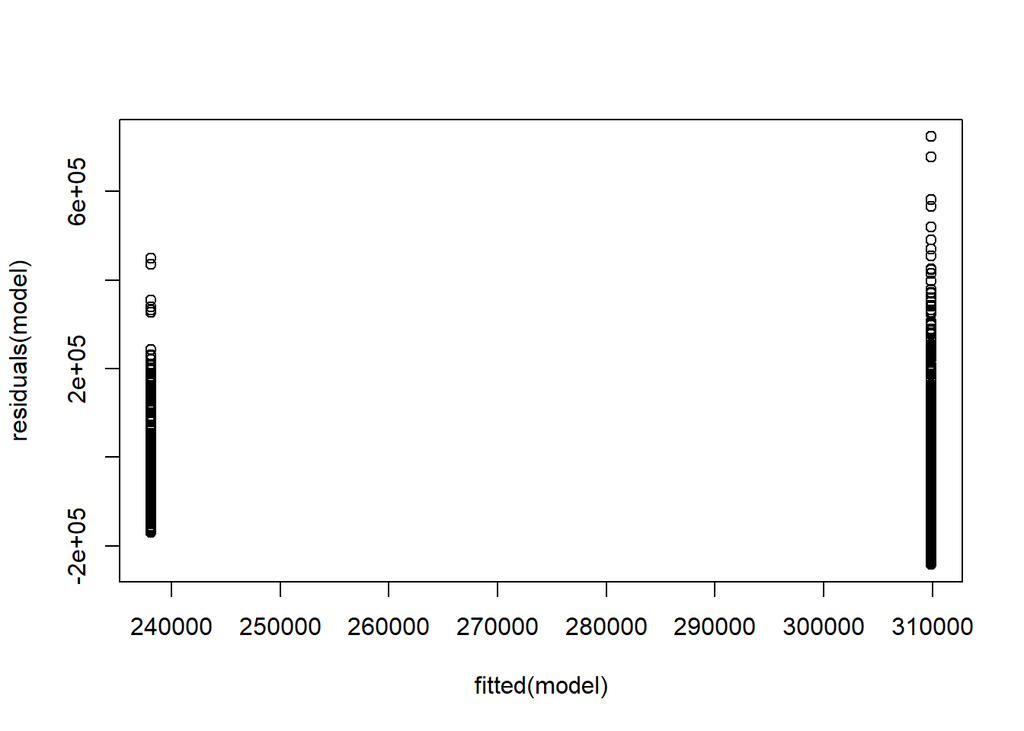

```r
#Plot for variance test
plot(fitted(model), residuals(model))
```

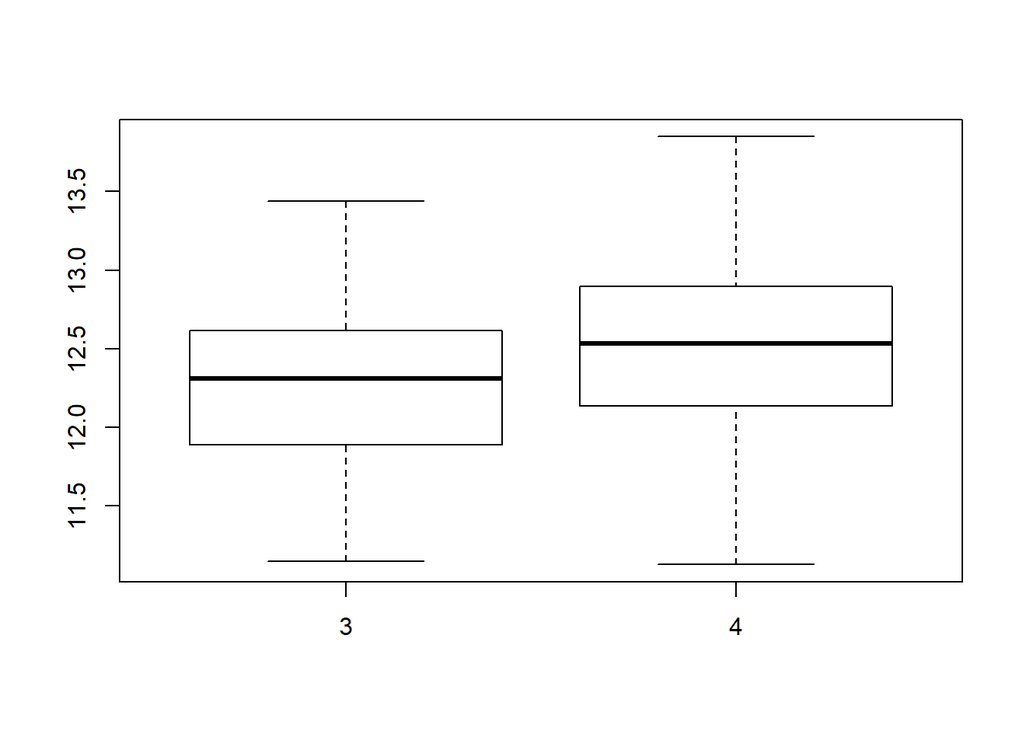

```r
#Both variance and noramlity test is violated, so we go for transformations

#Applying log transformations on Asset(dependent variable)
q10_filtered$log_asset <- log(q10_filtered$ASSET)
boxplot(q10_filtered$log_asset ~ factor(q10_filtered$EDCL))
```